# Water quality monitoring report, download date 2022-11_14

2022-11-16

### 1. Table of QAQC notes.

Created using field notes and visual interpretation of time series.

```
##              Start              End  Parameter Screen.label       Comment.short
## 1 10/14/2022 19:30  11/8/2022 12:30        ALL            X           Sonde dry
## 2  11/9/2022 14:20 11/15/2022 10:00        ALL            X        Sonde buried
## 3 10/15/2022 12:00 11/14/2022 18:10       TRYP          CAL        TRYP cal off
## 4 10/15/2022 12:00 11/14/2022 18:10 TURB.Manta          CAL  TURB.Manta cal off
## 5  11/8/2022 19:10   11/9/2022 0:30    TURB.SS            X    TURB.SS.TU error
## 6  11/8/2022 19:10   11/9/2022 0:30    TURB.SS            X    TURB.BS.TU error
## 7   11/9/2022 0:40   11/9/2022 5:30    TURB.SS          VAR TURB.SS.TU.variable
## 8   11/9/2022 0:40   11/9/2022 5:30    TURB.BS          VAR TURB.BS.TU.variable
##                                                                                                Comment.long
## 1                                                                                                 Sonde.dry
## 2                                                                 Sonde buried; cleaned by SG on 2022.11.15
## 3                                              TRYP calibration off by 10x; use RV and standard calibration
## 4 TURB Manta calibration error; cal log shows negative values for 100 NTU.  Use RV and standard calibration
## 5                                   TURB OBS SS low during peak of storm.  Possible occlusion of the sensor
## 6                                   TURB OBS BS low during peak of storm.  Possible occlusion of the sensor
## 7                                            TURB OBS SS high and variable.  May need additional smooothing
## 8                                            TURB OBS BS high and variable.  May need additional smooothing
```

### 2. Time series plot, entire period

Plot of all raw data, and final raw data used. Gray boxes indicate periods where all parameters were not valid. This can be caused by the sonde being dry, by significant biofouling, or by sedimentation on the sonde.

For November 14, 2022 download, the sonde was dry until Nov 8, and had significant sedimentation on Nov 9:

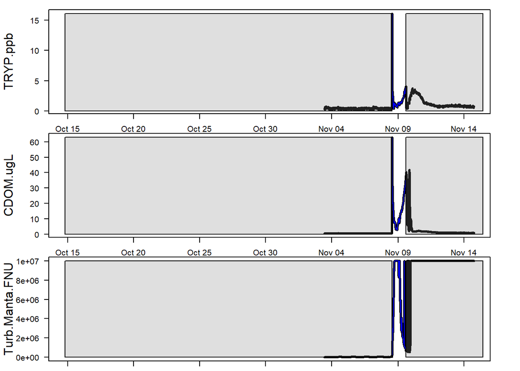